# Analysis and Visualization of Atlantic Hurricane Data (1975-2022)

DATA 612

Conie O’Malley & Diana Klinger

2024-08-10

```r
stormsData <- storms

rows <- nrow(stormsData)
col <- ncol(stormsData)
```

# 1 Introduction

This project aims to analyze and visualize the NOAA Atlantic hurricane database best track data, focusing on storm tracks from 1975 to 2022. The focus of our research is to analyze the question:

**Are hurricanes increasing in strength over time?**

We intend to measure strength using wind speed variables, but have additional variables of category, storm force diameter, and status to aid in our assessment and understand what the full scope of the data presents.

# 2 Data Overview

The `storms` dataset includes detailed information about storm positions and attributes, providing insights into the behavior and impact of tropical storms and hurricanes. The dataset contains 19537 observations and 13 variables, including storm name, date, time, location, storm classification, category, wind speed, air pressure, and diameters of tropical storm and hurricane force winds.

The data can be found on the [NOAA](https://www.nhc.noaa.gov/data/#hurdat) website.

The data is also available as a part of the dplyr package.

# 3 Data Description

## 3.1 Description

The variables in the dataset are as follows:

• *name:* The name of the storm

• *year, month, day:* The date of the report

• *hour:* The hour of the report (in UTC)

• *lat, long:* The latitude and longitude of the storm center

• *category:* The Saffir-Simpson hurricane category calculated from wind speed

• *wind:* The storm’s maximum sustained wind speed (in knots)

• *pressure:* The air pressure at the storm’s center (in millibars)

• *tropicalstorm_force_diameter:* The diameter of the area experiencing tropical storm strength winds (available starting in 2004)

• *hurricane_force_diameter:* The diameter of the area experiencing hurricane strength winds (available starting in 2004)

## 3.2 Summary Statistics

Below is the summary statistics and first few rows for the `storms` dataset.

```r
summary_stormsData <- summary(stormsData)

summary_stormsData
```

```
##      name                year          month             day
##  Length:19537       Min.   :1975   Min.   : 1.000   Min.   : 1.00
##  Class :character   1st Qu.:1994   1st Qu.: 8.000   1st Qu.: 8.00
##  Mode  :character   Median :2004   Median : 9.000   Median :16.00
##                     Mean   :2003   Mean   : 8.706   Mean   :15.73
##                     3rd Qu.:2013   3rd Qu.: 9.000   3rd Qu.:24.00
##                     Max.   :2022   Max.   :12.000   Max.   :31.00
##
##       hour             lat             long                         status
##  Min.   : 0.000   Min.   : 7.00   Min.   :-136.90   tropical storm     :6830
##  1st Qu.: 5.000   1st Qu.:18.30   1st Qu.: -78.80   hurricane          :4803
##  Median :12.000   Median :26.60   Median : -62.30   tropical depression:3569
##  Mean   : 9.101   Mean   :27.01   Mean   : -61.56   extratropical      :2151
##  3rd Qu.:18.000   3rd Qu.:33.80   3rd Qu.: -45.50   other low          :1453
##  Max.   :23.000   Max.   :70.70   Max.   :  13.50   subtropical storm  : 298
##                                                     (Other)            : 433
##     category          wind           pressure      tropicalstorm_force_diameter
##  Min.   :1.000   Min.   : 10.00   Min.   : 882.0   Min.   :   0.0
##  1st Qu.:1.000   1st Qu.: 30.00   1st Qu.: 986.0   1st Qu.:   0.0
##  Median :1.000   Median : 45.00   Median :1000.0   Median : 110.0
##  Mean   :1.896   Mean   : 50.05   Mean   : 993.5   Mean   : 147.9
##  3rd Qu.:3.000   3rd Qu.: 65.00   3rd Qu.:1007.0   3rd Qu.: 220.0
##  Max.   :5.000   Max.   :165.00   Max.   :1024.0   Max.   :1440.0
##  NA's   :14734                                     NA's   :9512
##  hurricane_force_diameter
##  Min.   :  0.00
##  1st Qu.:  0.00
##  Median :  0.00
##  Mean   : 14.92
##  3rd Qu.:  0.00
##  Max.   :300.00
##  NA's   :9512
```

```r
storm_head <- head(stormsData)
```

|  | name | year | month | day | hour | lat | long | status | category | wind | pressure | tropicalstorm_force_diameter | hurricane_force_diameter |
| --- | --- | --- | --- | --- | --- | --- | --- | --- | --- | --- | --- | --- | --- |
| 1 | Amy | 1975 | 6 | 27 | 0 | 27.5 | -79 | tropical depression |  | 25 | 1013 |  |  |
| 2 | Amy | 1975 | 6 | 27 | 6 | 28.5 | -79 | tropical depression |  | 25 | 1013 |  |  |
| 3 | Amy | 1975 | 6 | 27 | 12 | 29.5 | -79 | tropical depression |  | 25 | 1013 |  |  |
| 4 | Amy | 1975 | 6 | 27 | 18 | 30.5 | -79 | tropical depression |  | 25 | 1013 |  |  |
| 5 | Amy | 1975 | 6 | 28 | 0 | 31.5 | -78.8 | tropical depression |  | 25 | 1012 |  |  |
| 6 | Amy | 1975 | 6 | 28 | 6 | 32.4 | -78.7 | tropical depression |  | 25 | 1012 |  |  |

## 3.3 Tibble

```r
# determine if our data is stored in a tibble
if(is_tibble(stormsData)) {
  print("Dataset is a tibble.")
  } else {
      print("Dataset is not a tibble.")
  }
```

```
## [1] "Dataset is a tibble."
```

# 4 Data Preprocessing

## 4.1 Data Cleaning

We combined multiple date-related variables (year, month, day, and hour) into a single **datetime** variable. This new variable consolidates all the date and time information into a single column for easier analysis.

Next, we refined our dataset by selecting only the essential variables for our analysis and filtered the observations to include only the “hurricane” storm status. The first ten rows are displayed below.

```r
# mutate date variables into a single variable
stormsData <- stormsData %>%
  mutate(datetime = make_datetime(year, month, day, hour))

# remove unnecessary variables
stormsData <- stormsData %>%
  select(name, status, year, month, hour, category,
         wind, pressure, lat, long, datetime,
         hurricane_force_diameter) %>%
  filter(status == "hurricane")

ten <- head(stormsData, 10)
```

|  | name | status | year | month | hour | category | wind | pressure | lat | long | datetime | hurricane_force_diameter |
| --- | --- | --- | --- | --- | --- | --- | --- | --- | --- | --- | --- | --- |
| 1 | Blanche | hurricane | 1975 | 7 | 6 | 1 | 65 | 987 | 35.9 | -70 | 1975-07-27T06:00:00Z |  |
| 2 | Blanche | hurricane | 1975 | 7 | 12 | 1 | 70 | 984 | 36.9 | -69 | 1975-07-27T12:00:00Z |  |
| 3 | Blanche | hurricane | 1975 | 7 | 18 | 1 | 75 | 981 | 37.9 | -68 | 1975-07-27T18:00:00Z |  |
| 4 | Blanche | hurricane | 1975 | 7 | 0 | 1 | 75 | 980 | 39.3 | -67.2 | 1975-07-28T00:00:00Z |  |
| 5 | Blanche | hurricane | 1975 | 7 | 6 | 1 | 70 | 980 | 41.2 | -66.4 | 1975-07-28T06:00:00Z |  |
| 6 | Caroline | hurricane | 1975 | 8 | 0 | 1 | 65 | 990 | 23.3 | -94.2 | 1975-08-30T00:00:00Z |  |
| 7 | Caroline | hurricane | 1975 | 8 | 6 | 1 | 65 | 990 | 23.5 | -94.9 | 1975-08-30T06:00:00Z |  |
| 8 | Caroline | hurricane | 1975 | 8 | 12 | 1 | 65 | 989 | 23.7 | -95.6 | 1975-08-30T12:00:00Z |  |
| 9 | Caroline | hurricane | 1975 | 8 | 18 | 1 | 70 | 987 | 23.8 | -96.3 | 1975-08-30T18:00:00Z |  |
| 10 | Caroline | hurricane | 1975 | 8 | 0 | 3 | 100 | 973 | 24 | -97 | 1975-08-31T00:00:00Z |  |

## 4.2 Duplicates

```r
duplicates <- stormsData %>%
  group_by(name, datetime, lat, long) %>%
  filter(n() > 1) %>%
  ungroup() %>%
  distinct()

duplicate_count <- nrow(duplicates)
```

We performed a search for duplicates. The following 2 records in the dataset have the same storm name, date, time, and location, suggesting that these entries are duplicates.

|  | name | status | year | month | hour | category | wind | pressure | lat | long | datetime | hurricane_force_diameter |
| --- | --- | --- | --- | --- | --- | --- | --- | --- | --- | --- | --- | --- |
| 1 | Dolly | hurricane | 2008 | 7 | 18 | 1 | 75 | 967 | 26.4 | -97.2 | 2008-07-23T18:00:00Z | 50 |
| 2 | Ian | hurricane | 2022 | 9 | 18 | 1 | 70 | 978 | 33.3 | -79.2 | 2022-09-30T18:00:00Z | 40 |

## 4.3 Search for NA’s

We performed a search for “NA” values. The “NA” values we discovered were part of the **hurricane_force_diameter** variable. This will not impede our project, we will filter our “NA” values during our calculations in our analysis.

```r
# checking the number of NA values in the data set
overallNA_count <- stormsData %>%
  summarise_all(~sum(is.na(.)))
overallNA_count
```

| name | status | year | month | hour | category | wind | pressure | lat | long | datetime | hurricane_force_diameter |
| --- | --- | --- | --- | --- | --- | --- | --- | --- | --- | --- | --- |
| 0 | 0 | 0 | 0 | 0 | 0 | 0 | 0 | 0 | 0 | 0 | 2633 |

# 5 Data Visualizations

```r
# calculate wind speed by storm
stormWindSpeed <- stormsData %>%
  group_by(name, year) %>%
  summarise(meanWindSpeed = mean(wind, na.rm = TRUE)) %>%
  arrange(year)

# calculate average strength of storm per year over time
stormStrengthPerYear <- stormWindSpeed %>%
  group_by(year) %>%
  summarise(meanWindSpeedPerYear = mean(meanWindSpeed)) %>%
  arrange(year)
```

## 5.1 Wind Speed

### 5.1.1 Wind Speed by Year

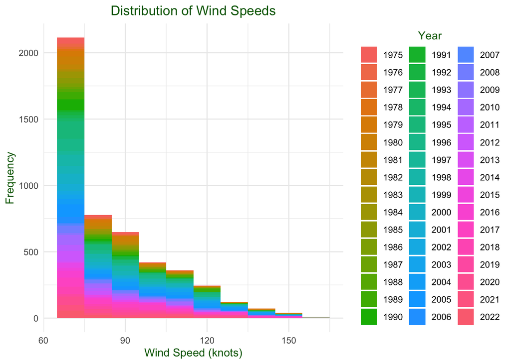

```r
ggplot(stormsData, aes(x = wind, fill = factor(year))) +
  geom_histogram(binwidth = 10) +
  labs(title = "Distribution of Wind Speeds",
       x = "Wind Speed (knots)",
       y = "Frequency",
       fill = "Year") +
  theme_minimal() +
  theme(plot.title = element_text(hjust = 0.5, color = "darkgreen"),
        axis.title = element_text(color = "darkgreen"),
        legend.title = element_text(color = "darkgreen", hjust = 0.5,))
```

### 5.1.2 Wind Speed by Storm

[figure not shown]

```r
stormStrengthPerYear_plot <- ggplot(data = stormStrengthPerYear,
                                    mapping = aes(x = year,
                                                  y = meanWindSpeedPerYear,
                                                  colour = year)) +
  geom_point() +
  geom_smooth(method = "lm", color = "darkblue") +
  labs(title = "Average Wind Speed per Year",
       x = "Year",
       y = "Average Wind Speed (mph)") +
  theme(plot.title = element_text(hjust = 0.5, color = "darkgreen"),
        axis.title = element_text(color = "darkgreen"),
        legend.title = element_text(" ", color = "darkgreen"))

stormStrengthPerYear_plot
```

### 5.1.3 Wind Speeds by Month

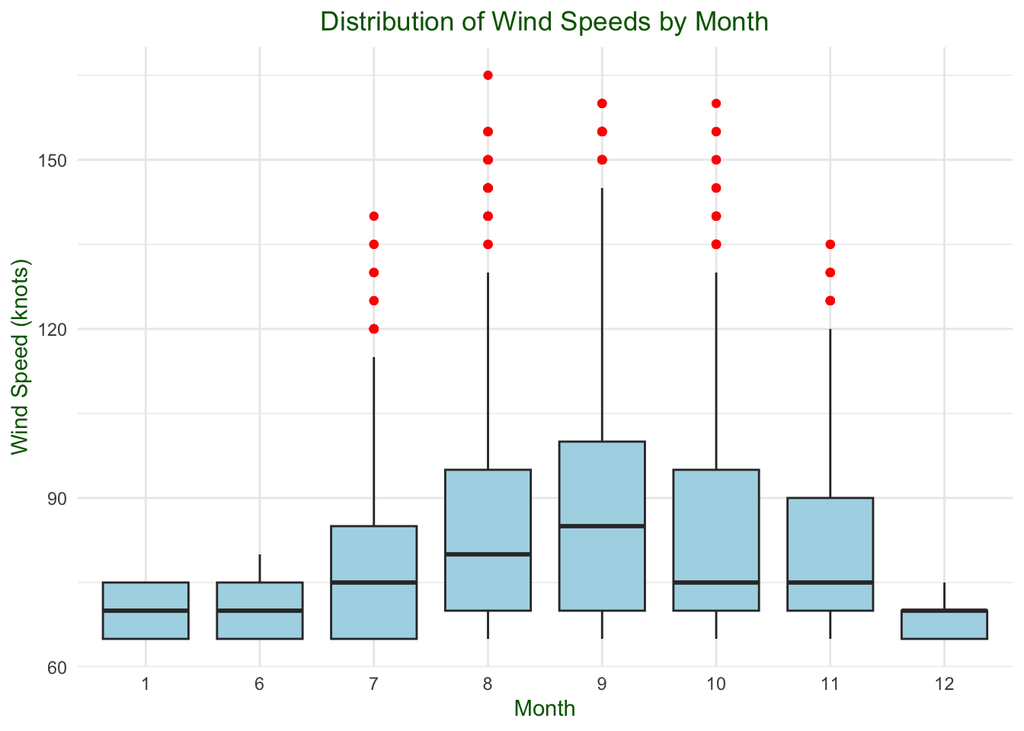

```r
ggplot(stormsData, aes(x = factor(month), y = wind)) +
  geom_boxplot(outlier.colour = "red", fill = "lightblue") +
  labs(title = "Distribution of Wind Speeds by Month",
       x = "Month",
       y = "Wind Speed (knots)") +
  theme_minimal() +
  theme(plot.title = element_text(hjust = 0.5, color = "darkgreen"),
        axis.title = element_text(color = "darkgreen"))
```

## 5.2 Air Pressure

```r
# calculate pressure by storm
stormPressure <- stormsData %>%
  group_by(name, year) %>%
  summarise(meanPressure = mean(pressure)) %>%
  arrange(year)

# calculate average pressure of storm per year over time
stormPressurePerYear <- stormPressure %>%
  group_by(year) %>%
  summarise(meanPressurePerYear = mean(meanPressure)) %>%
  arrange(year)
```

### 5.2.1 Pressure by Storm Category

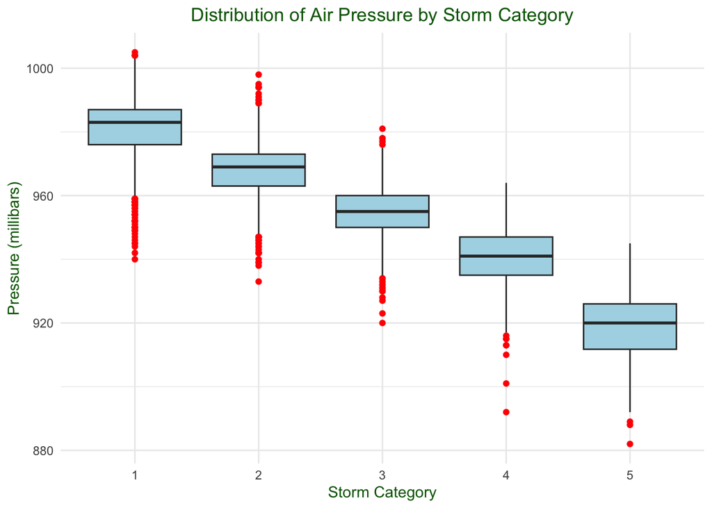

```r
ggplot(stormsData, aes(x = factor(category), y = pressure)) +
  geom_boxplot(outlier.colour = "red", fill = "lightblue") +
  labs(title = "Distribution of Air Pressure by Storm Category",
       x = "Storm Category",
       y = "Pressure (millibars)") +
  theme_minimal() +
  theme(axis.title = element_text(color = "darkgreen"),
        plot.title = element_text(hjust = 0.5, color = "darkgreen"))
```

### 5.2.2 Storm strength by pressure

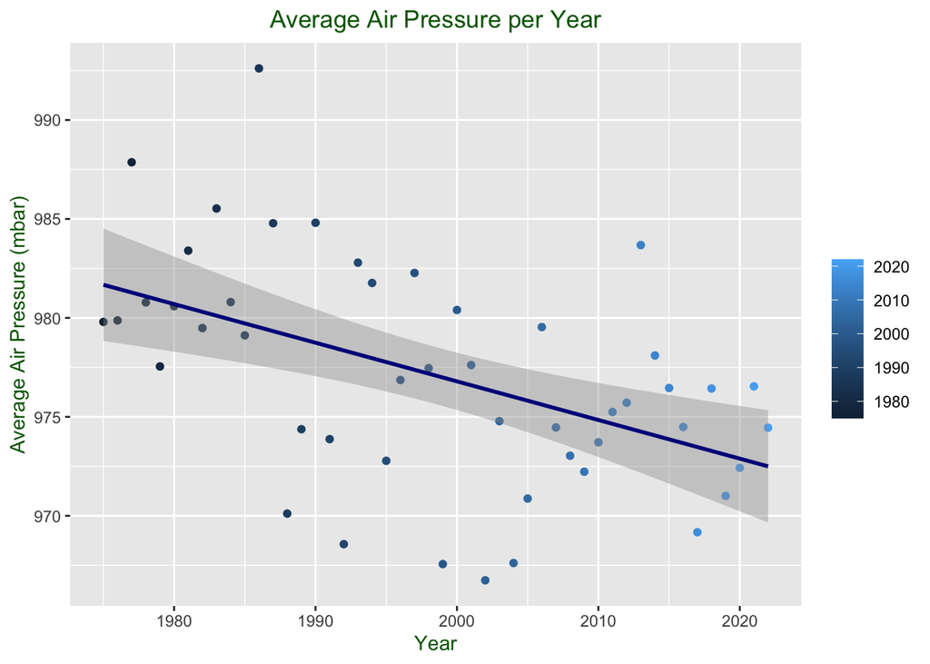

```r
stormPressurePerYear_plot <- ggplot(data = stormPressurePerYear,
                                    mapping = aes(x = year,
                                                  y = meanPressurePerYear,
                                                  colour = year)) +
  geom_point() +
  geom_smooth(method = "lm", color = "darkblue") +
  labs(title = "Average Air Pressure per Year",
       x = "Year",
       y = "Average Air Pressure (mbar)") +
  theme(plot.title = element_text(hjust = 0.5, color = "darkgreen"),
        axis.title = element_text(color = "darkgreen"),
        legend.title = element_text(" "))

stormPressurePerYear_plot
```

## 5.3 Hurricanes

### 5.3.1 Average Hurricane by Category per Year

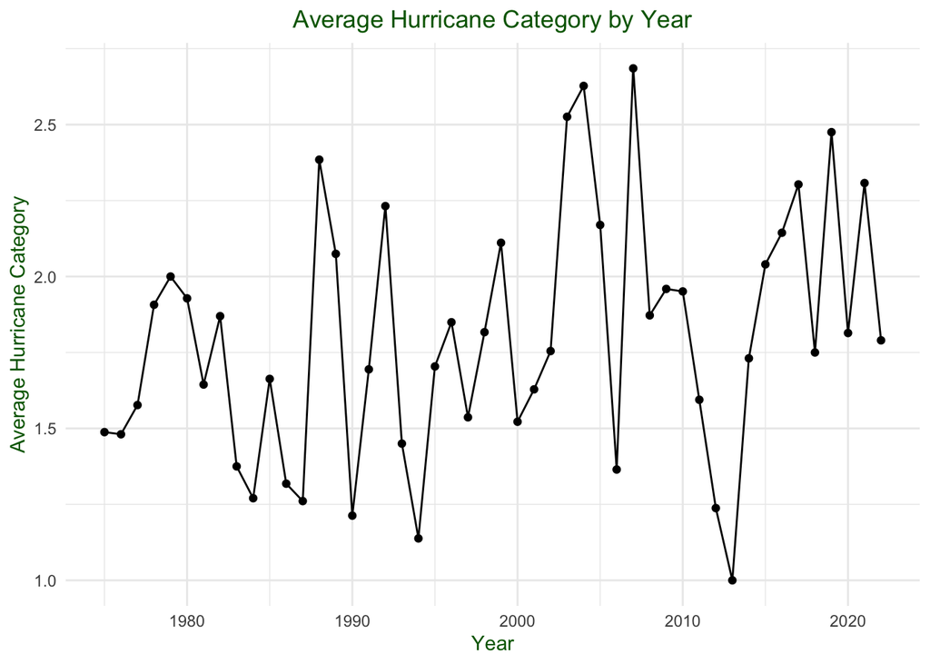

```r
# average hurricane category per year
avg_category_per_year <- stormsData %>%
  group_by(year) %>%
  summarise(avg_category = mean(category, na.rm = TRUE))

ggplot(avg_category_per_year, aes(x = year, y = avg_category)) +
  geom_line() +
  geom_point() +
  labs(title = "Average Hurricane Category by Year",
       x = "Year",
       y = "Average Hurricane Category") +
  theme_minimal() +
  theme(plot.title = element_text(hjust = 0.5, color = "darkgreen"),
        axis.title = element_text(color = "darkgreen"))
```

```r
# calculate hurricane strength by category by year
hurricaneStrength <- stormsData %>%
  filter(status == "hurricane") %>%
  group_by(category, year) %>%
  summarise(count = n()) %>%
  arrange(year)

# calculate average hurricane strength per year
hurricaneStrengthPerYear <- hurricaneStrength %>%
  group_by(year) %>%
  summarise(meanStrength = mean(category))
```

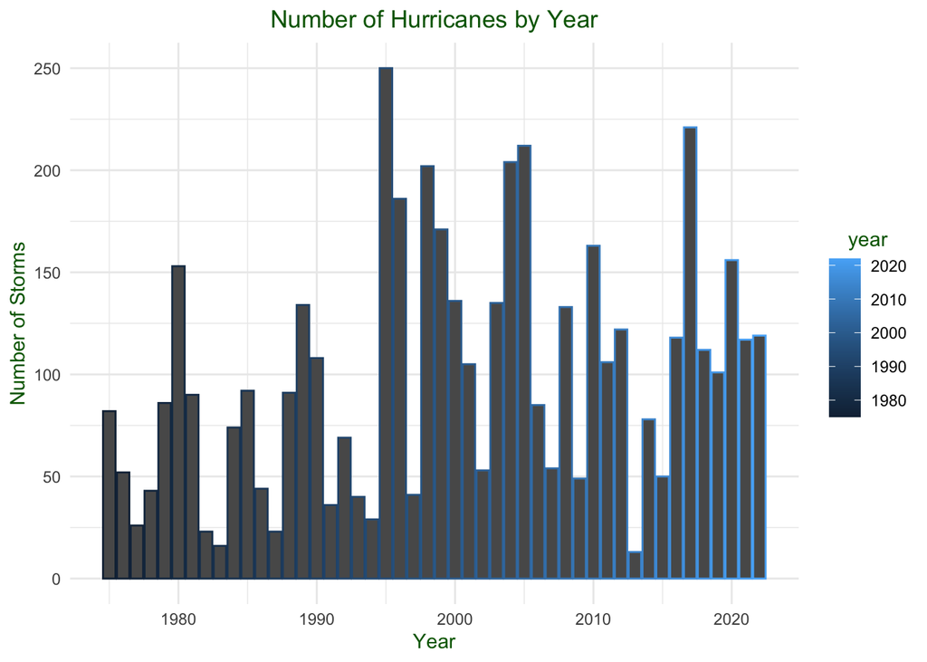

```r
# maximum wind speed per year
max_wind_per_year <- stormsData %>%
  group_by(year) %>%
  summarise(max_wind = max(wind, na.rm = TRUE))

storm_stats <- stormsData %>%
  group_by(year) %>%
  summarise(storm_count = n())

ggplot(storm_stats, aes(x = year, y = storm_count, color = year)) +
  geom_bar(stat = "identity") +
  labs(title = "Number of Hurricanes by Year",
       x = "Year",
       y = "Number of Storms") +
  theme_minimal() +
  theme(plot.title = element_text(color = "darkgreen", hjust = 0.5),
        axis.title = element_text(color = "darkgreen"),
        legend.title = element_text(color = "darkgreen", hjust = 0.5))
```

## 5.4 Comparison Charts

### 5.4.1 Pressure & storm strength relationship

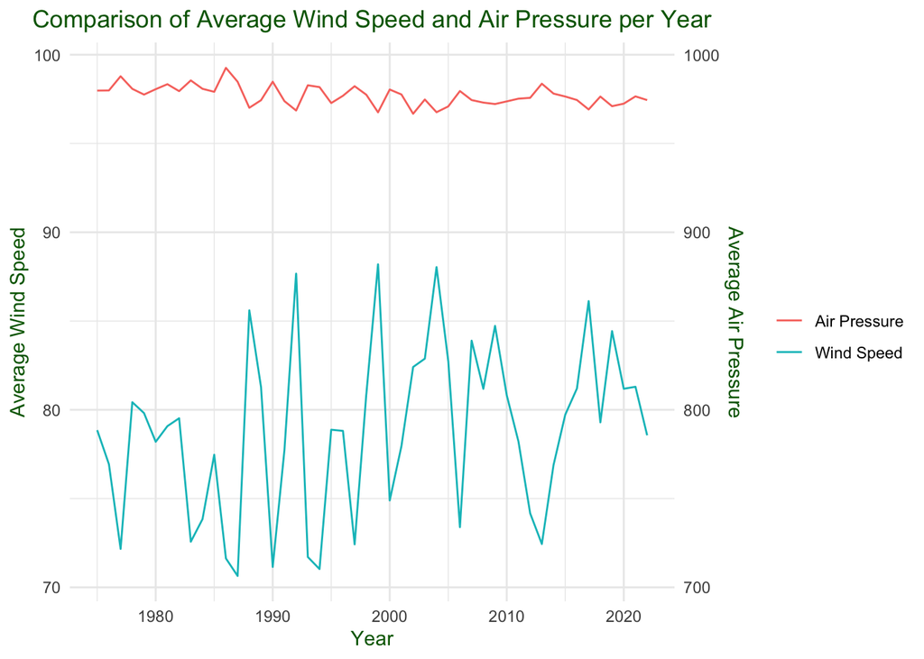

```r
# combining previously calculated variables to create new visualizations
combinedPressureAndWindData <- stormStrengthPerYear %>%
  left_join(stormPressurePerYear, by = "year")

combinedPressureAndWind_plot <- ggplot(data = combinedPressureAndWindData,
                                       mapping = aes(x = year)) +
  geom_line(aes(y = meanWindSpeedPerYear, color = "Wind Speed")) +
  geom_line(aes(y = meanPressurePerYear/10, color = "Air Pressure")) +
  scale_y_continuous(name = "Average Wind Speed",
                     sec.axis = sec_axis(~ . * 10,
                                         name = "Average Air Pressure")) +
  labs(title = "Comparison of Average Wind Speed and Air Pressure per Year",
       x = "Year",
       color = "Variable") +
  theme_minimal() +
  theme(plot.title = element_text(color = "darkgreen", hjust = 0.5),
        axis.title = element_text(color = "darkgreen"),
        legend.title = element_text(" "))

combinedPressureAndWind_plot
```

### 5.4.2 Wind, Pressure, and Hurricane Force Diameter Correlation

This is our “new” component. We utilized the corrplot package and library to visualize a correlation matrix featuring the quantitative variables. The method parameter determines how the correlations are visually represented in the plot. We selected the “ellipse” method where the shape and orientation of the ellipses represent the strength and direction of the correlations. A perfectly circular ellipse represents no correlation while the elongated ellipses indicate stronger correlations. The direction of the elongation shows whether the correlation is positive or negative. Next, we set the order parameter to “hclust”. The variables are grouped into clusters based on their correlation and then ordered according to these clusters instead of the order in which they appear in the matrix.

```r
# Correlation Analysis
quantitative_vars <- stormsData %>%
  select(wind, pressure, hurricane_force_diameter)

correlation_matrix <- cor(quantitative_vars, use = "complete.obs")

correlation_matrix
```

```
##                                wind   pressure hurricane_force_diameter
## wind                      1.0000000 -0.8865148                0.3571258
## pressure                 -0.8865148  1.0000000               -0.5970737
## hurricane_force_diameter  0.3571258 -0.5970737                1.0000000
```

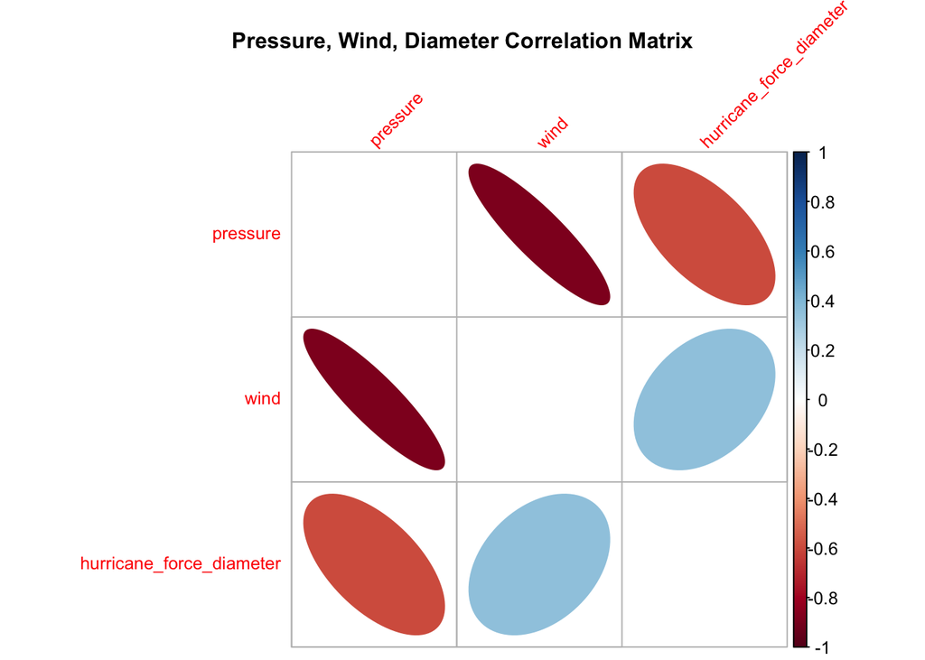

```r
par(mar = c(7, 4, 7, 2))

corrplot(correlation_matrix,
         method = "ellipse",
         order = "hclust",
         diag = F,
         tl.cex = 0.8,
         cl.pos = 'r',
         tl.srt = 45)

mtext("Pressure, Wind, Diameter Correlation Matrix",
      side = 3,
      line = 5,
      cex = 1,
      font = 2,
      adj = 0.5)
```

Interpretation of the Correlation Matrix:

**wind/pressure:** Strong negative correlation. As wind speeds increase, pressure tends to decrease.

**wind/hurricane_force_diameter:** Weak to moderate positive correlation. As wind speeds increase, the diameter of hurricane force winds also tends to increase.

**pressure/hurricane_force_diameter:** Moderate negative correlation. As pressure decreases, the diameter of hurricane-force winds tends to increase. But this is not as strong as the correlation between wind and pressure.

# 6 Trend Analysis

## 6.1 Category based linear model

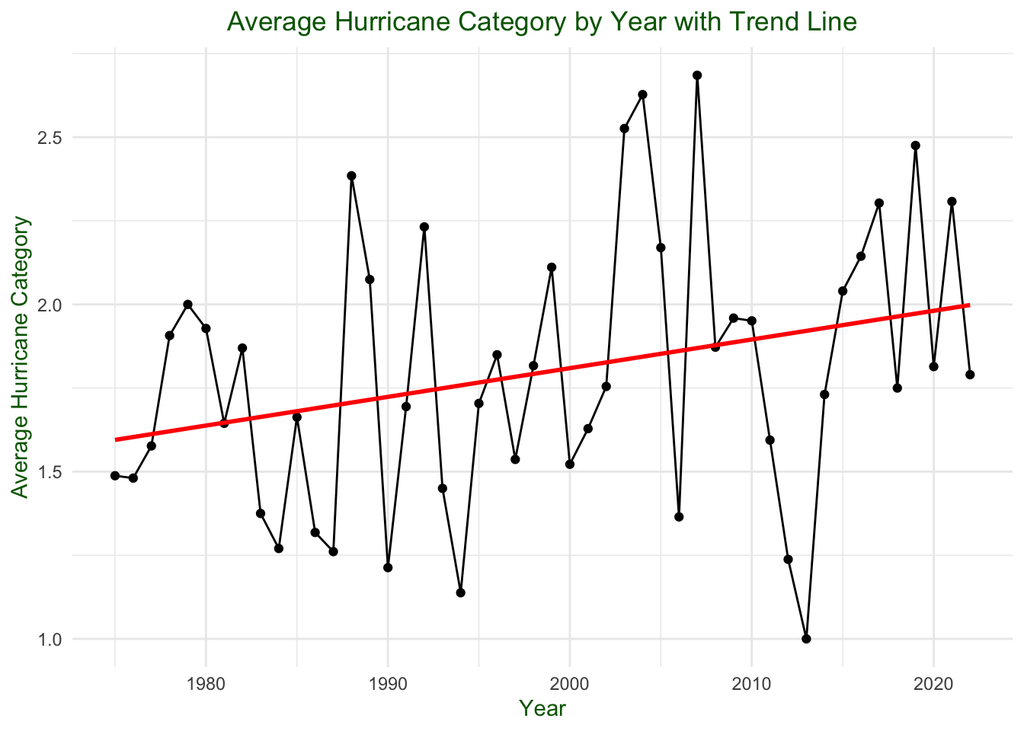

```r
# average hurricane category per year
avg_category_per_year <- stormsData %>%
  group_by(year) %>%
  summarise(avg_category = mean(category, na.rm = TRUE))

# linear model for average category
model_avg_category <- lm(avg_category ~ year, data = avg_category_per_year)

modelCategoryPerYear_plot <- ggplot(avg_category_per_year,
                                    aes(x = year, y = avg_category)) +
  geom_line() +
  geom_point() +
  geom_smooth(method = "lm", se = FALSE, color = "red") +
  labs(title = "Average Hurricane Category by Year with Trend Line",
       x = "Year",
       y = "Average Hurricane Category") +
  theme_minimal() +
  theme(plot.title = element_text(color = "darkgreen", hjust = 0.5),
        axis.title = element_text(color = "darkgreen"),
        legend.title = element_text(color = "darkgreen"))

modelCategoryPerYear_plot
```

## 6.2 Wind speed based linear model

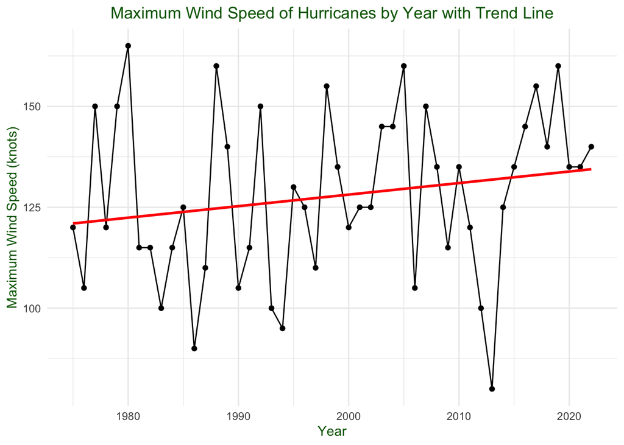

```r
# linear model for maximum wind speed
model_wind <- lm(max_wind ~ year, data = max_wind_per_year)

modelWindSpeedPerYear_plot <- ggplot(max_wind_per_year,
                                     aes(x = year, y = max_wind)) +
  geom_line() +
  geom_point() +
  geom_smooth(method = "lm", se = FALSE, color = "red") +
  labs(title = "Maximum Wind Speed of Hurricanes by Year with Trend Line",
       x = "Year",
       y = "Maximum Wind Speed (knots)") +
  theme_minimal() +
  theme(plot.title = element_text(color = "darkgreen", hjust = 0.5),
        axis.title = element_text(color = "darkgreen"),
        legend.title = element_text(color = "darkgreen"))

modelWindSpeedPerYear_plot
```

# 7 Conclusion

```r
# averages by category
avg_cat_1975 <- avg_category_per_year %>%
  filter(year == 1975) %>%
  pull(avg_category) %>%
  round(2)

avg_cat_2020 <- avg_category_per_year %>%
  filter(year == 2020) %>%
  pull(avg_category) %>%
  round(2)

# averages by wind speed
avg_wind_per_year <- stormsData %>%
  group_by(year) %>%
  summarise(avg_wind_speed = mean(wind, na.rm = TRUE))

avg_wind_1975 <- avg_wind_per_year %>%
  filter(year == 1975) %>%
  pull(avg_wind_speed) %>%
  round(2)

avg_wind_2020 <- avg_wind_per_year %>%
  filter(year == 2020) %>%
  pull(avg_wind_speed) %>%
  round(2)

# % change calculations
percentage_change <- function(new_value, old_value) {
  sprintf("%.0f%%",
          round(( (new_value - old_value) / old_value) * 100, 0))
}

avg_cat_change <- percentage_change(avg_cat_2020, avg_cat_1975)

avg_wind_change <- percentage_change(avg_wind_2020, avg_wind_1975)
```

After reviewing the data, we can see a clear increase in the intensity of hurricanes between 1975 - 2022. Both our Category Based and Wind Speed Based models show an upward trend in their respective metrics. The average hurricane category has increased from 1.49 to 1.81, approximately 21%, while the average hurricane windspeed has increased from 79.33 to 85.38 knots, approximately 8%.

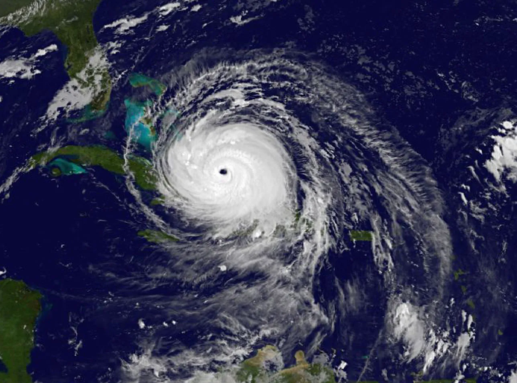

Project by Diana Klinger ’24 and [Conie O’Malley](https://www.linkedin.com/in/conor-e-o-malley/) ’25